# Introduktion til registerdata og forløbsanalyse

## Dagens program

I dag lægger i forlængelse af introduktionen i sidste uge, fokus er at få styr på grundbegreberne før vi bevæger os videre. I dag bliver derfor mere “teknisk”, i modsætning til forelæsningerne herfra.

- Hvorfor (og hvornår) arbejder vi med `registerdata`.
- Hvorfor (og hvornår) arbejder vi med `forløbsanalyse`.
- Repitation af grundbegreber.
  - (Simpel) Kaplan-Meier: `kode` og `output`.
  - Dagens øvelse.

## Forventet udbytte

### *Viden*

- Indsigt i de danske **registerdata**.
- Indblik i fordelene ved **longitudinale** data.
- Indblik i `R`-pakker relevant for **forløbsanalyse**.

### *Færdigheder*

- **Indlæse** data.
- **Datamanagement** i `R`.
- Simple **analyser** i `R`.
  - *Kaplan-Meier* overlevelsesanalyse i `R`.

### *Kompetancer*

- **Analyse** og **tolkning** af en “simpel” *Kaplan-Meier* overlevelsesanalyse.

# Hvordan får vi mest ud af dette kursus og de planlagte øvelser?

# Hvorfor arbejder vi med `registerdata`?

## Hønen eller ægget?

[figure not shown]

## De danske `registerdata`.

[Link til bestillinglisten](https://www.dst.dk/extranet/forskningvariabellister/Oversigt%20over%20registre.html)

[figure not shown]

## Typer af `dataformater` i danske registre. (1)

- **Statusregistre** opgjort på bestemte datoer (e.g., 1. januar, hvert år).
  - `BEF`: Befolkningen.
- **Hændelsesregistre** for bestemte begivenheder i bestemte tisperioder.
  - `DOD`: Døde i Danmark.
- **Enheder** i registrene.
  - Individer (`CPR`, anonymiseret som `PNR`).
  - Familier (`FAMILIE_ID`).
  - Virksomheder (`CVR`).
  - Uddannelsesinstitutioner (`INSTNR`).
  - Osv `...`

## Typer af `dataformater` i danske registre. (2)

Hvilke implikationer har dataformaterne for `tidsenheder`?

- `Discrete-time` metoder: modellerer `odds`.
- `Continues-time` metoder: modellerer `hazard rate`.
- Mere herom i de efterfølgende forelæsninger, hvor vi også har fokus på `censurering`.

# Første berøring med registerdata

```r
df <- haven::read_sas("//Volumes//oecon-forloeb24//Råfiler//pnr_sample.sas7bdat")
```

Selvom dette blot er et 1% sample og “kun” indeholder 2.008.567 observationer (individer) og 88 variable, tager det lige under 2 min. at læse ind i `R` med `read_sas()` funktionen fra `haven`-pakken.

Al rå registerdata kommer som `.sas7bdat`-format.

## Betingelserne for at kunne lave en forløbsanalyse er:

- `Måling af om en begivenheden finder sted`.
- `At vi kan observere tiden fra start til begivenhed` (eller censurering).
- Dette kan udtrykkes i forskellige data-strukturer. Primært:
  - `Single-episode file`: Hver enhed (fx en patient) har præcis én episode i filen. Én række per unikt subjekt. Indeholder typisk aggregerede oplysninger eller en enkeltstående hændelse, som dækker hele observationsperioden.
  - `Multi-episode file`: Hver enhed kan have flere episoder i filen. Flere rækker per unikt subjekt, hvor hver række repræsenterer en unik episode. Hver række har en start- og slutdato samt oplysninger om hændelsen.
  - **`Subject-Period file`**: Én række per unik kombination af enhed og en defineret periode (fx en måned, et år). Opsummerer information om alle episoder, der er sket i perioden.

**SPG:** Hvilken struktur har vores **“flyttedata”**?

## Mål(ene) for overlevelsesanalyse

1. Estimation af `overlevelses` og `fordelings`-funktionerne.

$$S(t) = P(\{T>t\}) = \int_{t}^{\infty} f(u)du = 1-F(t)$$

$S(t)$ – **Overlevelsesfunktionen**: Angiver sandsynligheden for, at tidsintervallet $T$ (dvs. tiden fra start til hændelsen) er større end $t$, dvs. at hændelsen endnu *ikke* har indtruffet ved tid $t$.

Vi kan udtrykke denne sandsynlighed som integralet for *probability density function* (**pdf**; tæthedsfunktionen). Med andre ord, sandsynligheden beregnes som arealet under **pdf** $f(u)$ fra $t$ til $\infty$.

Dermed er $F(t)$ den kummulative distributions funktion (**cdf**) af $T$, ssandsynligheden for, at hændelsen *har* indtruffet inden tid $t$, hvorfor $1-F(t)$ er sandsynligheden for, at hændelsen ikke er indtruffet (altså $T>t$).

$du$ repræsenterer en “infinitesimal” ændring i $u$.

## Eksempel med en `exponential` **pdf** (1)

### Kode

```r
S.t <-
  function(t, h) {
  return(1 - pexp(t, rate = h))
  }

t <- seq(0, 50, by = 1)
h <- 0.1

S.t.teoretisk <- S.t(t, h)
```

### Output

| t |
| --- |
| 1.0000000 |
| 0.9048374 |
| 0.8187308 |
| 0.7408182 |
| 0.6703200 |
| 0.6065307 |
| 0.5488116 |
| 0.4965853 |
| 0.4493290 |
| 0.4065697 |

## Eksempel med en `exponential` **pdf** (2)

### Kode

```r
S.t <-
  function(t, h) {
  return(1 - pexp(t, rate = h))
  }

t <- seq(0, 50, by = 1)
h <- 0.1

S.t.teoretisk <- S.t(t, h)
```

### Output

| t |
| --- |
| 1.0000000 |
| 0.9048374 |
| 0.8187308 |
| 0.7408182 |
| 0.6703200 |
| 0.6065307 |
| 0.5488116 |
| 0.4965853 |
| 0.4493290 |
| 0.4065697 |

## Eksempel med en `exponential` **pdf** (3)

### Kode

```r
S.t <-
  function(t, h) {
  return(1 - pexp(t, rate = h))
  }

t <- seq(0, 50, by = 1)
h <- 0.1

S.t.teoretisk <- S.t(t, h)
```

### Output (afrundet)

| t |
| --- |
| 1.00 |
| 0.90 |
| 0.82 |
| 0.74 |
| 0.67 |
| 0.61 |
| 0.55 |
| 0.50 |
| 0.45 |
| 0.41 |

## Eksempel med en `exponential` **pdf** (4)

### Kode

```r
S.t <-
  function(t, h) {
  return(1 - pexp(t, rate = h))
  }

t <- seq(0, 50, by = 1)
h <- 0.1

S.t.teoretisk <- S.t(t, h)
```

[output not shown]

$h$ er vores *rate parameter* for den exponentielle distribution. $h(t)$ repræsenterer `failures per unit of time`. Her er den sat til $h = 0.1$. **I praksis estimerer vi denne parameter.**

### Output

## Eksempel med en `exponential` **pdf** (5)

### Kode

```r
S.t <-
  function(t, h) {
  return(1 - pexp(t, rate = h))
  }

t <- seq(0, 50, by = 1)
h <- 0.1

S.t.teoretisk <- S.t(t, h)
```

[output not shown]

Udtryk anderledes, `probability density funktionen` (**pdf**), $f(t)$, bestemmer “styrken” af en begivenheds sandsynlighed ved:

$$h(t) = \frac{ f(t) } { \hat{S}(t) }$$

Med andre ord, $h$ $\equiv$ **hazard rate**.

### Output

## Eksempel med en `exponential` **pdf** (6)

### Kode

```r
S.t <-
  function(t, h) {
  return(1 - pexp(t, rate = h))
  }

t <- seq(0, 50, by = 1)
h <- 0.1

S.t.teoretisk <- S.t(t, h)
```

[output not shown]

følger det at:

- Jo højere $h$:
  - des “stejlere” bliver overlevelsesfunktionen,
  - des hurtigere bliver $S(t) = 0$,
  - des hurtigere bliver $F(t) = 1$.

### Output

## Eksempel med en `exponential` **pdf** (7)

### Kode

```r
S.t <-
  function(t, h) {
  return(1 - pexp(t, rate = h))
  }

t <- seq(0, 50, by = 1)
h <- 0.6

S.t.teoretisk <- S.t(t, h)
```

Hvad sker der så når vi ændrer værdien af **hazard rate** ($h(t)$)?

### Output

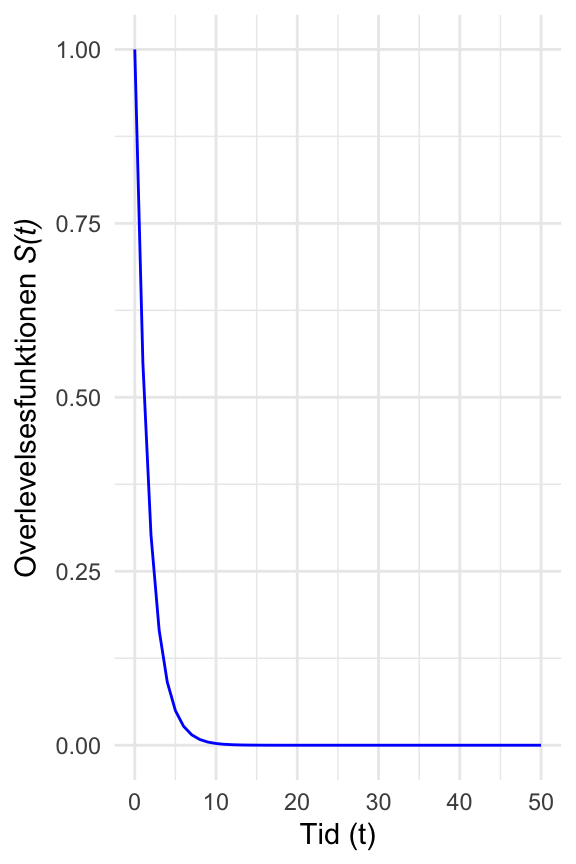

## Eksempel med en `exponential` **pdf** (8)

### Kode

```r
S.t <-
  function(t, h) {
  return(1 - pexp(t, rate = h))
  }

t <- seq(0, 50, by = 1)
h <- 0.01

S.t.teoretisk <- S.t(t, h)
```

Hvad sker der så når vi ændrer værdien af **hazard rate** ($h(t)$)?

### Output

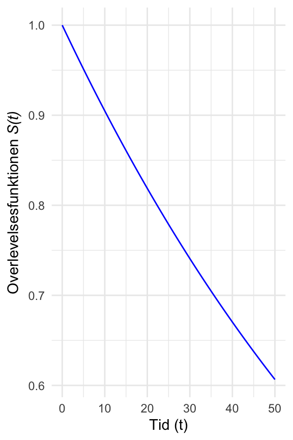

## Eksempel med en `exponential` **pdf** (9)

### Kode

```r
S.t <-
  function(t, h) {
  return(1 - pexp(t, rate = h))
  }

t <- seq(0, 50, by = 1)

list <- list()
for (i in seq(0.05, 0.95, by = .1)) {
  out <- S.t(t, i)
  h <- as.character(i)
  out %<>% tibble(t, out, h)
  list[[h]] <- out
}
hs <- do.call("rbind.data.frame",
              list)
```

Hvad sker der så når vi ændrer værdien af **hazard rate** ($h(t)$)?

### Output

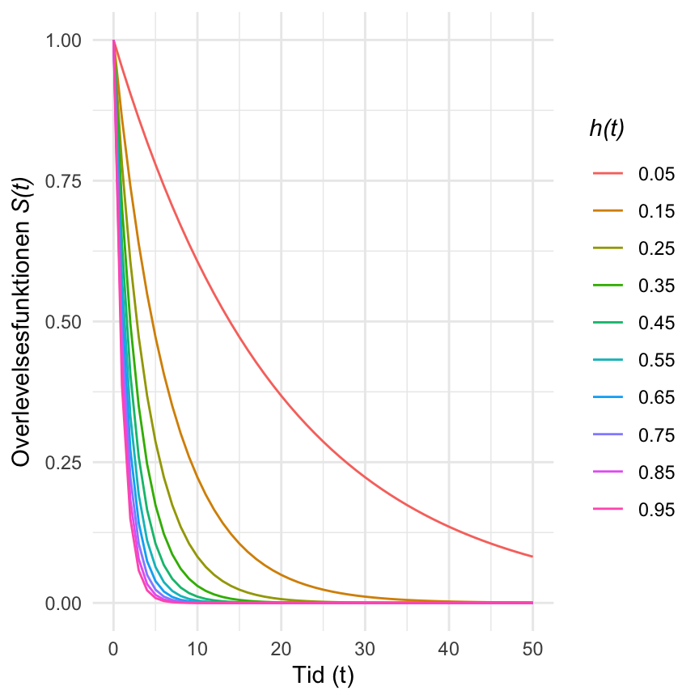

## `Hazard funktionen` (1)

Hazardfunktionen, også kaldet den betingede fejlrate, beskriver den øjeblikkelige risiko for, at hændelsen indtræffer i tidsintervallet $\left[ t, t+\Delta t \right]$, givet at hændelsen endnu ikke har fundet sted ved tid $t$. Dette understreger, at vi har med en rate at gøre—som kan antage værdier fra 0 til $\infty$—og ikke med en direkte sandsynlighed. Formelt defineres den som:

$$h(t) = \lim_{{\Delta t \to 0}} \frac{{P(t < T \leq t + \Delta t \,|\, T > t)}}{{\Delta t}}$$

${P(t < T \leq t + \Delta t \,|\, T > t)}$ angiver sandsynligheden for, at hændelsen indtræffer i et kort tidsinterval efter $t$, forudsat at enheden har overlevet indtil $t$. Udtrykket $\lim_{{\Delta t \to 0}}$ betyder, at vi betragter den **øjeblikkelige hændelsesrate**.

Sammenhængen mellem hazardfunktionen $h(t)$ og overlevelsesfunktionen $S(t)$ kan udtrykkes som den negative integral af hazard functionen:

$$S(t) = \text{exp} \left[ -\int_{0}^{t} h(u)du \right]$$

hvilket også implicerer, at:

$$h(t) = -\left[ \frac{dS(t)/dt}{S(t)} \right]$$

## `Hazard funktionen` (2)

Indtil nu har vi derfor antaget den **øjeblikkelige hændelsesrate**, $\lim_{{\Delta t \to 0}}$, er konstant over tid.

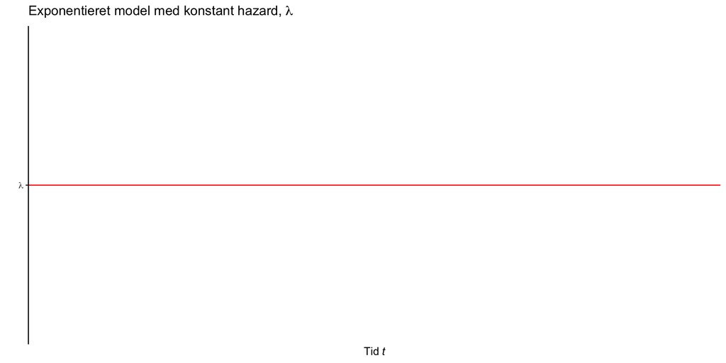

## `Hazard funktionen`: “shapes” (1)

### Kode

```r
h.exp <- survival::dexp(time, rate = 1)
h.weibull <- survival::dweibull(time, shape = 2, scale = 1)
h.lognormal <- survival::dlnorm(time, meanlog = 0, sdlog = 1)
```

### Output

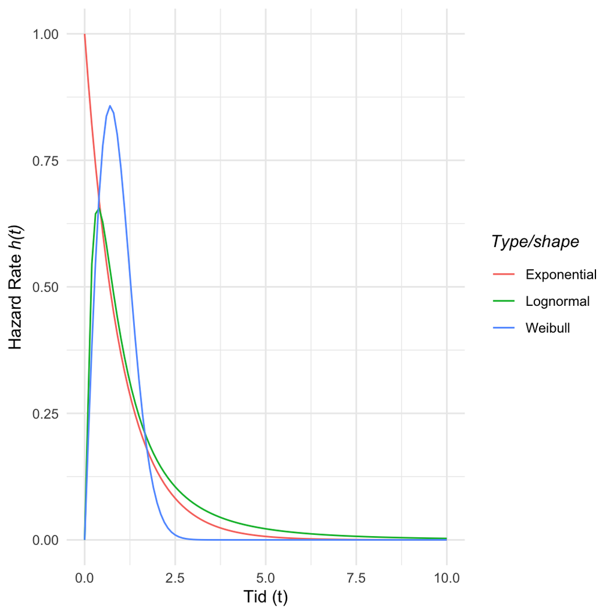

## `Hazard funktionen`: “shapes” (2)

### Kode

```r
h.exp <- dexp(t, rate = 1)
h.weibull <- dweibull(t, shape = 2, scale = 1)
h.lognormal <- dlnorm(t, meanlog = 0, sdlog = 1)
```

### Output

[figure not shown]

## `Hazard funktionen`: “shapes” (3)

### Kode

```r
h.exp <- dexp(t, rate = 1)
h.weibull <- dweibull(t, shape = 2, scale = 4)
h.lognormal <- dlnorm(t, meanlog = 0, sdlog = 1)
```

### Output

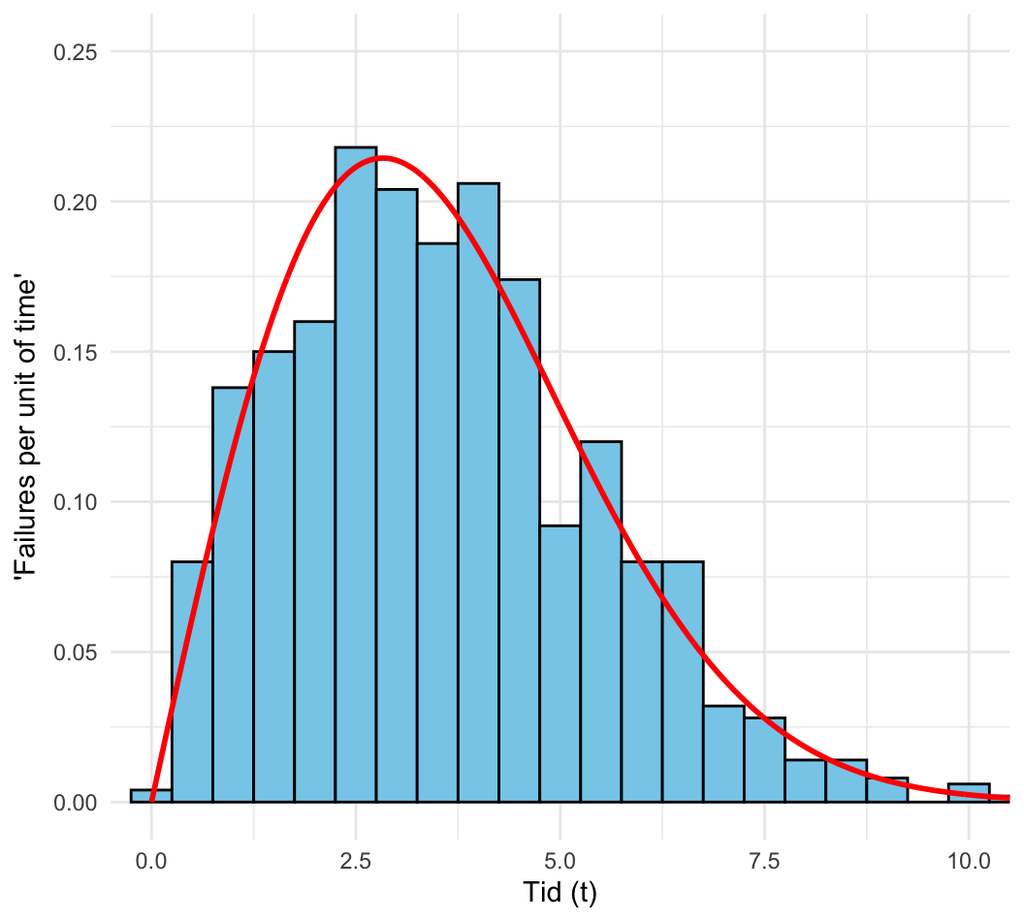

## `Hazard funktionen`: “shapes” (4)

### Kode

```r
h.exp <- dexp(t, rate = 1)
h.weibull <- dweibull(t, shape = .5, scale = 1)
h.lognormal <- dlnorm(t, meanlog = 0, sdlog = 1)
```

### Output

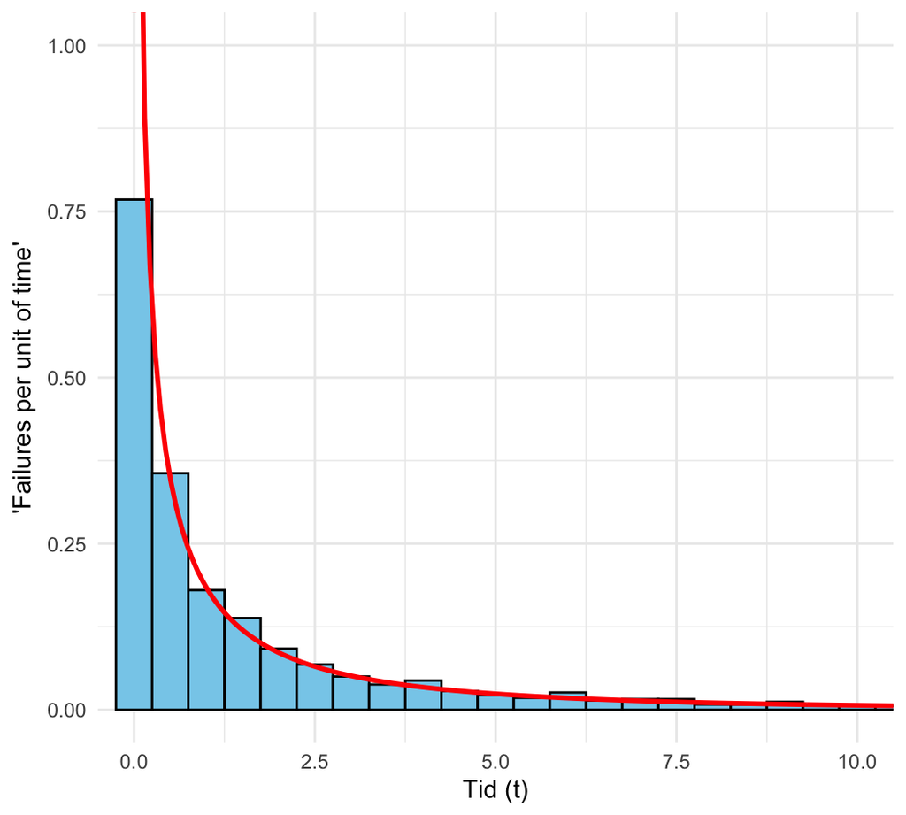

## `Hazard funktionen`: “shapes” (5)

### Kode

```r
h.exp <- dexp(t, rate = 1)
h.weibull <- dweibull(t, shape = 2, scale = 1)
h.lognormal <- dlnorm(t, meanlog = 0, sdlog = 1)
```

### Output

[figure not shown]

## Og hvad så `...` ? (1)

Et af målene i overlevelsesanalysen er at sammenligne $S(t)$ og $h(t)$ mellem populationer/grupper, fordi det fortæller noget om hvordan mekanismer påvirker dem forskelligt, *såfremt de er forskellige*.

## Og hvad så `...` ? (1)

- **Gruppe 1**: Observerede hændelser

### Kode

```r
n <- 1000
shape <- 2
scale <- 4

data <- rweibull(n, shape = shape, scale = scale)
df <- data.frame(Data = data)
weibull_density <- dweibull(seq(0, max(df$Data), length.out = 1000), shape = shape, scale = scale)
```

### Output

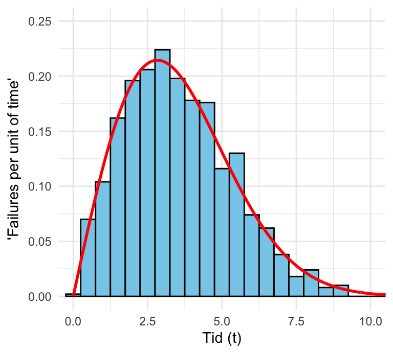

## Og hvad så `...` ? (2)

- **Gruppe 1**: Estimeret $S(t)$ (bemærk hvordan fordelingen af hændelser “kommer til udtryk” i kurven)

### Kode

```r
n <- 1000
shape <- 2
scale <- 4

data <- rweibull(n, shape = shape, scale = scale)
df <- data.frame(Data = data)
weibull_density <- dweibull(seq(0, max(df$Data), length.out = 1000), shape = shape, scale = scale)

surv_fit <- survfit2(Surv(data) ~ 1)
```

### Output

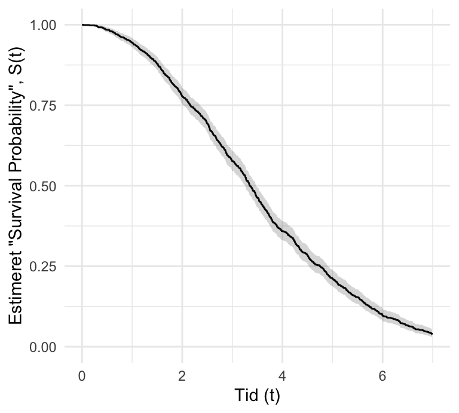